# 【TaskC】Handling missing values

##### !!! please DO NOT rename this file !!!

### 【TaskC】Dealing with missing values

- student id:111524019
- name：陳品蓁

### 此次任務中一共有兩份資料集，一份是完整的資料，一份是有遺漏值的資料，如下所示：

### There are two datasets in this task. One is the complete data and the other is the data with missing value:

```
- 完整資料/complete data：'StudentsPerformance.csv'
- 有遺漏值/with missing values：'StudentsPerformance_miss.csv'
```

#### 【Q1】在第一題中，請使用「有遺漏值」的資料完成以下任務：

##### 1. 在有遺漏值的檔案中，遺漏值並不是以空值nan的形式呈現，請撰寫程式來確認此份資料是以什麼符號表示遺漏值，並附上執行過程

##### 2. 若遺漏值不是nan形式，會無法執行pandas的遺漏值函式。因此，請將檔案中的遺漏值轉換成nan的形式，並附上執行過程

##### 3. 請找出此份資料中哪幾個欄位有遺漏值，及遺漏值的數量，並附上執行過程

#### 【Q1】In question1, please use dataset "with missing value" to finish the following tasks：

##### 1. In the file with missing value, missing values are not presented as nan. Please write code to check out which character are use to present the missing value.(must show how you do it)

##### 2. Please transfer the missing value into nan.(must show how you do it)

##### 3. Please find out which columns have missing values and the amount of missing value.(must show how you do it)

```python
import pandas as pd
import numpy as np
completedata=pd.read_csv('StudentsPerformance.csv')
missingdata=pd.read_csv('StudentsPerformance_miss.csv')
missingdata.info() #得到數據的特性可以看到Dtype 有些是object有些是int64
missingdata.describe()
missingdata_unique=missingdata.reading_score.unique() #使用者個函數可以叫出Column 中所有直
np.sort(missingdata_unique)
#可以發現目前的缺失值是*
```

```
<class 'pandas.core.frame.DataFrame'>
RangeIndex: 1000 entries, 0 to 999
Data columns (total 9 columns):
 #   Column                       Non-Null Count  Dtype
---  ------                       --------------  -----
 0   Unnamed: 0                   1000 non-null   int64
 1   gender                       1000 non-null   object
 2   race/ethnicity               1000 non-null   object
 3   parental level of education  1000 non-null   object
 4   lunch                        1000 non-null   object
 5   test preparation course      1000 non-null   object
 6   math_score                   1000 non-null   object
 7   reading_score                1000 non-null   object
 8   writing_score                1000 non-null   object
dtypes: int64(1), object(8)
memory usage: 70.4+ KB
```

```
array(['*', '100', '17', '23', '24', '26', '28', '29', '31', '32', '34',
       '37', '38', '39', '40', '41', '42', '43', '44', '45', '46', '47',
       '48', '49', '50', '51', '52', '53', '54', '55', '56', '57', '58',
       '59', '60', '61', '62', '63', '64', '65', '66', '67', '68', '69',
       '70', '71', '72', '73', '74', '75', '76', '77', '78', '79', '80',
       '81', '82', '83', '84', '85', '86', '87', '88', '89', '90', '91',
       '92', '93', '94', '95', '96', '97', '99'], dtype=object)
```

```python
missingdata=pd.read_csv('StudentsPerformance_miss.csv',na_values="*")#使用這個將原本*的值換成nan
missingdata_unique=missingdata.reading_score.unique()
np.sort(missingdata_unique)#可以觀察到*值已換成nan
```

```
array([ 17.,  23.,  24.,  26.,  28.,  29.,  31.,  32.,  34.,  37.,  38.,
        39.,  40.,  41.,  42.,  43.,  44.,  45.,  46.,  47.,  48.,  49.,
        50.,  51.,  52.,  53.,  54.,  55.,  56.,  57.,  58.,  59.,  60.,
        61.,  62.,  63.,  64.,  65.,  66.,  67.,  68.,  69.,  70.,  71.,
        72.,  73.,  74.,  75.,  76.,  77.,  78.,  79.,  80.,  81.,  82.,
        83.,  84.,  85.,  86.,  87.,  88.,  89.,  90.,  91.,  92.,  93.,
        94.,  95.,  96.,  97.,  99., 100.,  nan])
```

```python
missingdata.isna()#可觀察到每一項的nan，並用布林值顯示
```

|  | Unnamed: 0 | gender | race/ethnicity | parental level of education | lunch | test preparation course | math_score | reading_score | writing_score |
| --- | --- | --- | --- | --- | --- | --- | --- | --- | --- |
| 0 | False | False | False | False | False | False | False | False | False |
| 1 | False | False | False | False | False | False | False | False | False |
| 2 | False | False | False | False | False | False | False | False | False |
| 3 | False | False | False | False | False | False | False | False | False |
| 4 | False | False | False | False | False | False | False | False | False |
| ... | ... | ... | ... | ... | ... | ... | ... | ... | ... |
| 995 | False | False | False | False | False | False | False | False | False |
| 996 | False | False | False | False | False | False | False | False | False |
| 997 | False | False | False | False | False | False | False | False | False |
| 998 | False | False | False | False | False | False | False | False | False |
| 999 | False | False | False | False | False | False | False | False | False |

1000 rows × 9 columns

```python
missingdata.isna().sum()#計算布林值為true的數量有多少
#math_score/reading_score/writing_score 欄位有遺漏值
```

```
Unnamed: 0                      0
gender                          0
race/ethnicity                  0
parental level of education     0
lunch                           0
test preparation course         0
math_score                     50
reading_score                  77
writing_score                  56
dtype: int64
```

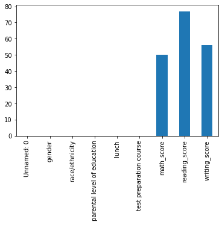

```python
import matplotlib.pyplot as plt
missingdata.isna().sum().plot(kind="bar")
#長條圖顯示數量多寡
```

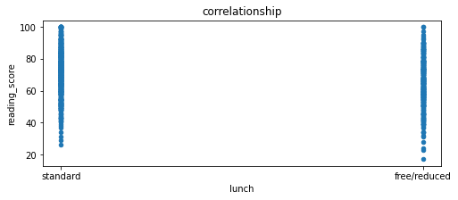

```python
missingdata.plot(kind='scatter',title='correlationship',figsize=(8,3),x='lunch',y='reading_score',marker='o')
#相關係數圖(lunch跟reading_score的關系)
```